# OysterCode

Ruby K

2022-06-18

Return to [Oyster Study Progress](https://rmk118.github.io/oyster-study)

To see all code and the raw output of any significance tests, see the [OysterCode](https://rmk118.github.io/oyster-study/OysterCode.html) page

## Contents

- Initial Shell Dimensions
- Outside Floating Bag Replacement
- First Sampling Day

## Initial Shell Dimensions

```r
initialHeights1<-c(63,32,48,61,71,41,58,69,33,34,70,61,61,51,39,45,61,60,61,67,60,55,40,69,55,29,60,46,46,53,75,42,21,35,72,61,48,46,47,73,55,31,43,37,52,56,52,40,63,48,50,19,59,59,47,63,41,41,26,35,48,64,44,60,40,49,47,35,55,45,60,42,42,46,49,56,48,45,40,37,60,59,37,28,51,61,45,35,26,54,41,44,58,39,41,47,34,47,50,52,55,43,44,45,41,26,50,38,41,58,42,37,36,48,28,24,32,29,45,70,64,67,24,35,63,56,41,37,47,55,38,75,47,43,40,39,65,50,42,42,40,60,28,36,60,64,48,48,50,49,33,34,40,43,59,46,30,38,58,43,45,35,34,37,48,58,58,42,46,57,44,24,40,40,41,37,59,57,68,40,45,49,50,35,35,30,36,30,32,70,34,41,54,29,43,52,32,37,38,70,42,32,56,37,35,58,50,38,42,43,55,60,43,68,46,60,53,55,59,55,32,50,41,64,37,59,57,52,55,50,38,60,61,37,60,62,55,45,63,47,35,62,61,65,36,62,59,42,39,49,35,50,49,46,43,45,34,44,44,30,41,49,45,41,42,48,32,80,69,69,50,46,57,45,59,63,56,51,45,51)
```

```r
oysterAvgInitial<-mean(initialHeights1)
oysterAvgInitial
```

```
## [1] 47.63929
```

```r
initialHeightSD<-sd(initialHeights1)
initialHeightSD
```

```
## [1] 11.72085
```

```r
shapiro.test(initialHeights1)
```

```
##
##  Shapiro-Wilk normality test
##
## data:  initialHeights1
## W = 0.9884, p-value = 0.02423
```

```r
upperLimit<-oysterAvgInitial+2*initialHeightSD
upperLimit
```

```
## [1] 71.08099
```

```r
lowerLimit<-oysterAvgInitial-2*initialHeightSD
lowerLimit
```

```
## [1] 24.19758
```

```r
initialHeights<-data.frame(initialHeights1)
```

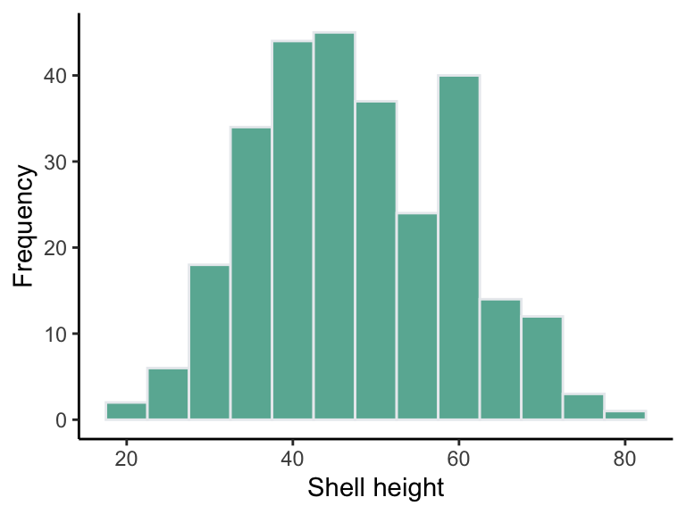

```r
library(ggplot2)
ggplot(initialHeights,aes(x=initialHeights1))+geom_histogram(binwidth = 5, fill="#69b3a2", color="#e9ecef")+theme_classic()+xlab("Shell height")+ylab("Frequency")
```

Figure #1: Initial distribution of shell heights in population used to stock experimental gear (n=280)

## Outside Floating Bag Replacement

At some point during the initial sampling day (6/14), the middle floating bag outside the pound became detached from the line and could not be recovered. A replacement bag was stocked from the “leftover” oysters in the population used to stock the original experimental gear. These leftover oysters were being stored in a submerged plastic crate attached to the dock within the North Pound. Only 7 full days had elapsed since the initial stocking was completed, so it was hypothesized that the oysters in the source population would not yet show significant morphological differences from those in the experimental gear.

The replacement ADPI bag was filled with 175 oysters selected in the same manner as the initial treatments (i.e., randomly chosen from the larger population, excluding any animals that were dead, strongly fused together, or had a shell height outside the range of 71.08-24.2 mm).

Before the placement bag was deployed, a random sample of 32 oysters was collected for comparison to the samples (n=32 for each bag) taken the previous day from the three initial outside ADPI bags. Shapiro-Wilk and Levene’s tests were employed to assess the ANOVA assumptions of normality and homoscedasticity, respectively.

No assumptions were violated for height and length, so a one-way ANOVA was used to determine if significant differences existed between any of the four outside ADPI bags— the three original bags plus the replacement bag.

The shell width distributions were non-normal for both the original bag #2 (p=0.0231) and the replacement bag #2 (p=0.04589). As such, the nonparametric Kruskal-Wallis test was used in place of the ANOVA.

Testing height for homoscedasticity (no violation)

```r
SamplingOne<-read.csv("6_14.csv")
FBout<-SamplingOne[SamplingOne$Treatment == "FBo",]
library(car)
NewBag<-as.character(FBout$Bag)
FBout$Bag<-NewBag
height.levene<-leveneTest(Height~Bag, data=FBout)
```

Testing height for normality (no violations)

```r
bag1height<- FBout[FBout$Bag == "1","Height"]
bag1height.normality<-shapiro.test(bag1height) #Normal
bag2height<- FBout[FBout$Bag == "2","Height"]
bag2height.normality<-shapiro.test(bag2height) #Normal
bag3height<- FBout[FBout$Bag == "3","Height"]
bag3height.normality<-shapiro.test(bag3height) #Normal
bag4height<- FBout[FBout$Bag == "Rep","Height"]
bag4height.normality<-shapiro.test(bag4height) #Normal
```

Height ANOVA: no significant differences

```r
HeightResults<-aov(Height~Bag, data=FBout)
summary(HeightResults)
```

```
##              Df Sum Sq Mean Sq F value Pr(>F)
## Bag           3    437   145.6   1.427  0.238
## Residuals   124  12656   102.1
```

Testing length for homoscedasticity (no violation)

```r
length.levene<-leveneTest(Length~Bag, data=FBout)
```

Testing length for normality (no violations)

```r
bag1length<- FBout[FBout$Bag == "1","Length"]
shapiro.test(bag1length) #Normal
```

```
##
##  Shapiro-Wilk normality test
##
## data:  bag1length
## W = 0.96472, p-value = 0.3677
```

```r
bag2length<- FBout[FBout$Bag == "2","Length"]
shapiro.test(bag2length) #Normal
```

```
##
##  Shapiro-Wilk normality test
##
## data:  bag2length
## W = 0.9538, p-value = 0.1847
```

```r
bag3length<- FBout[FBout$Bag == "3","Length"]
shapiro.test(bag3length) #Normal
```

```
##
##  Shapiro-Wilk normality test
##
## data:  bag3length
## W = 0.96006, p-value = 0.2757
```

```r
bag4length<- FBout[FBout$Bag == "Rep","Length"]
shapiro.test(bag4length) #Normal
```

```
##
##  Shapiro-Wilk normality test
##
## data:  bag4length
## W = 0.97333, p-value = 0.596
```

Length ANOVA: no significant differences

```r
LengthResults<-aov(Length~Bag, data=FBout)
summary(LengthResults)
```

```
##              Df Sum Sq Mean Sq F value Pr(>F)
## Bag           3    286   95.31   2.547  0.059 .
## Residuals   124   4640   37.42
## ---
## Signif. codes:  0 '***' 0.001 '**' 0.01 '*' 0.05 '.' 0.1 ' ' 1
```

Testing width for homoscedasticity (no violation)

```r
leveneTest(Width~Bag, data=FBout)
```

```
## Levene's Test for Homogeneity of Variance (center = median)
##        Df F value Pr(>F)
## group   3  1.9622 0.1231
##       124
```

Testing width for normality (assumption violated)

```r
bag1width<- FBout[FBout$Bag == "1","Width"]
shapiro.test(bag1width) #Normal
```

```
##
##  Shapiro-Wilk normality test
##
## data:  bag1width
## W = 0.94412, p-value = 0.09806
```

```r
bag2width<- FBout[FBout$Bag == "2","Width"]
shapiro.test(bag2width) #Not normal, p=0.0231
```

```
##
##  Shapiro-Wilk normality test
##
## data:  bag2width
## W = 0.92168, p-value = 0.0231
```

```r
bag3width<- FBout[FBout$Bag == "3","Width"]
shapiro.test(bag3width) #Normal
```

```
##
##  Shapiro-Wilk normality test
##
## data:  bag3width
## W = 0.93566, p-value = 0.05645
```

```r
bag4width<- FBout[FBout$Bag == "Rep","Width"]
shapiro.test(bag4width) #Not normal, p=0.04589
```

```
##
##  Shapiro-Wilk normality test
##
## data:  bag4width
## W = 0.93246, p-value = 0.04589
```

Width Kruskal-Wallis: no significant differences

```r
kruskal.test(Width~Bag, data=FBout)
```

```
##
##  Kruskal-Wallis rank sum test
##
## data:  Width by Bag
## Kruskal-Wallis chi-squared = 2.2322, df = 3, p-value = 0.5256
```

A one-way ANOVA is considered robust to violations of the normality assumption (e.g., Schmider et al., 2010). If an ANOVA is run on the width data despite the noted normality violations, again no significant differences are found.

```r
WidthResults<-aov(Width~Bag, data=FBout)
summary(WidthResults)
```

```
##              Df Sum Sq Mean Sq F value Pr(>F)
## Bag           3   16.1   5.375   0.595  0.619
## Residuals   124 1119.9   9.031
```

Conclusion: no significant differences were found between the height, length, or widths of the oysters in any of the outside ADPI bags, including the replacement bag. For future analysis of growth and shell morphology, the replacement bag will be analyzed as if it were the original outside bag #2. However, biofouling did appear to be more severe on the replacement oysters than on the oysters in the original outside ADPI bags. As such, when oysters are selected from each treatment for biofouling analysis at the conclusion of the experiment, the outside FB sample will be collected from only bags #1 and #3.

### Within-bag Variability

Within-bag or within-cage variability for each floating bag and cage treatment in given location were assessed using a one-way ANOVA or, if assumptions were not met, a Kruskal-Wallis test. Within-bag variability for outside FB is described above.

##### Inside Floating Bags

```r
FBin<-SamplingOne[SamplingOne$Treatment == "FBi",]
#Testing variances (all good)
leveneTest(Height~Bag, data=FBin)
```

```
## Levene's Test for Homogeneity of Variance (center = median)
##       Df F value Pr(>F)
## group  2  0.1794 0.8361
##       93
```

```r
leveneTest(Length~Bag, data=FBin)
```

```
## Levene's Test for Homogeneity of Variance (center = median)
##       Df F value Pr(>F)
## group  2   1.943  0.149
##       93
```

```r
leveneTest(Width~Bag, data=FBin)
```

```
## Levene's Test for Homogeneity of Variance (center = median)
##       Df F value Pr(>F)
## group  2  0.3904 0.6779
##       93
```

```r
#Testing height for normality (assumption violated)
bag1height_in<- FBin[FBin$Bag == "1","Height"]
shapiro.test(bag1height_in)
```

```
##
##  Shapiro-Wilk normality test
##
## data:  bag1height_in
## W = 0.97318, p-value = 0.5915
```

```r
bag2height_in<- FBin[FBin$Bag == "2","Height"]
shapiro.test(bag2height_in)
```

```
##
##  Shapiro-Wilk normality test
##
## data:  bag2height_in
## W = 0.96302, p-value = 0.3315
```

```r
bag3height_in<- FBin[FBin$Bag == "3","Height"]
shapiro.test(bag3height_in) #p=0.04558
```

```
##
##  Shapiro-Wilk normality test
##
## data:  bag3height_in
## W = 0.93236, p-value = 0.04558
```

```r
#Testing length for normality (all good)
bag1length_in<- FBin[FBin$Bag == "1","Length"]
shapiro.test(bag1length)
```

```
##
##  Shapiro-Wilk normality test
##
## data:  bag1length
## W = 0.96472, p-value = 0.3677
```

```r
bag2length_in<- FBin[FBin$Bag == "2","Length"]
shapiro.test(bag2length_in)
```

```
##
##  Shapiro-Wilk normality test
##
## data:  bag2length_in
## W = 0.9378, p-value = 0.06487
```

```r
bag3length_in<- FBin[FBin$Bag == "3","Length"]
shapiro.test(bag3length_in)
```

```
##
##  Shapiro-Wilk normality test
##
## data:  bag3length_in
## W = 0.96969, p-value = 0.491
```

```r
#Testing width for normality (assumptions violated)
bag1width_in<- FBin[FBin$Bag == "1","Width"]
shapiro.test(bag1width_in) #Bag 1 not normal, p<0.001
```

```
##
##  Shapiro-Wilk normality test
##
## data:  bag1width_in
## W = 0.85016, p-value = 0.0004182
```

```r
bag2width_in<- FBin[FBin$Bag == "2","Width"]
shapiro.test(bag2width_in) #Bag 2 not normal, p=0.02344
```

```
##
##  Shapiro-Wilk normality test
##
## data:  bag2width_in
## W = 0.92192, p-value = 0.02344
```

```r
bag3width_in<- FBin[FBin$Bag == "3","Width"]
shapiro.test(bag3width_in) #Bag 3 good
```

```
##
##  Shapiro-Wilk normality test
##
## data:  bag3width_in
## W = 0.95573, p-value = 0.2092
```

```r
#Testing for significant differences between inside FB
FBin.height.interbag<-kruskal.test(Height~Bag, data=FBin)
FBin.length.interbag<-aov(Length~Bag, data=FBin)
summary(FBin.length.interbag)
```

```
##             Df Sum Sq Mean Sq F value Pr(>F)
## Bag          2    298  149.09   3.607  0.031 *
## Residuals   93   3844   41.34
## ---
## Signif. codes:  0 '***' 0.001 '**' 0.01 '*' 0.05 '.' 0.1 ' ' 1
```

```r
FBin.width.interbag<-kruskal.test(Width~Bag, data=FBin)
```

There were no significant differences in shell height between the three inside floating bags (Kruskal-Wallis test, H(2)=3.724, p=0.155). Similarly, no significant differences in shell width were observed between the three bags (Kruskal-Wallis test, H(2)=1.501, p=0.472).

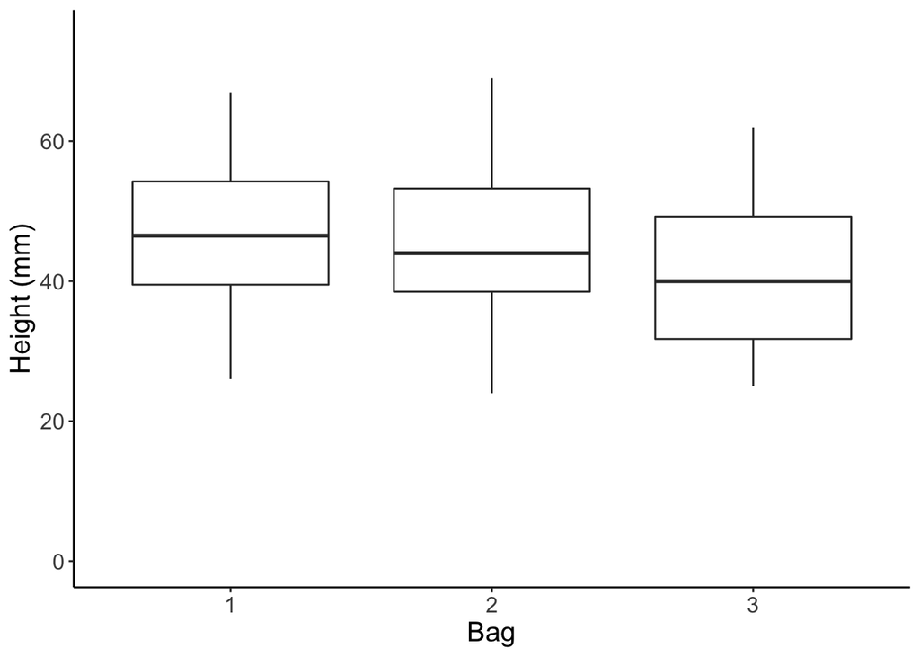

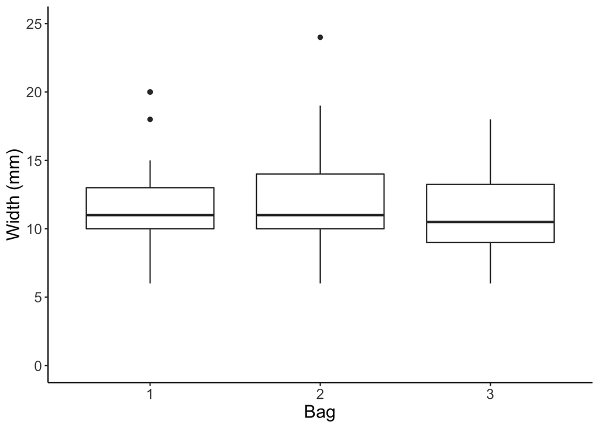

```r
ggplot(data = FBin, aes(x = Bag, y = Height))+geom_boxplot()+theme_classic()+xlab("Bag")+ylab("Height (mm)")+theme(text = element_text(size=15))+scale_y_continuous(limits=c(0,75))

ggplot(data = FBin, aes(x = Bag, y = Width))+geom_boxplot()+theme_classic()+xlab("Bag")+ylab("Width (mm)")+theme(text = element_text(size=15))+scale_y_continuous(limits=c(0,25))
```

However, the three inside floating bags did significantly differ with regards to shell length (One-way ANOVA, F(2,93)=3.607, p=0.031).

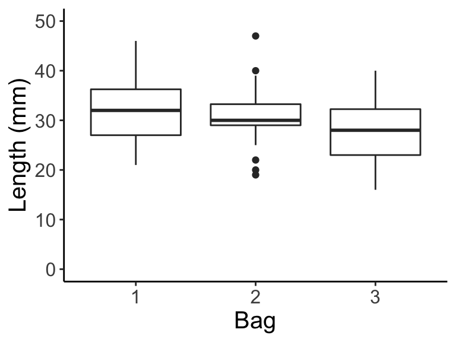

```r
ggplot(data = FBin, aes(x = Bag, y = Length))+geom_boxplot()+theme_classic()+xlab("Bag")+ylab("Length (mm)")+theme(text = element_text(size=15))+scale_y_continuous(limits=c(0,50))
```

Figure #4: Shell length of oysters in inside floating bags

### Graphical Results

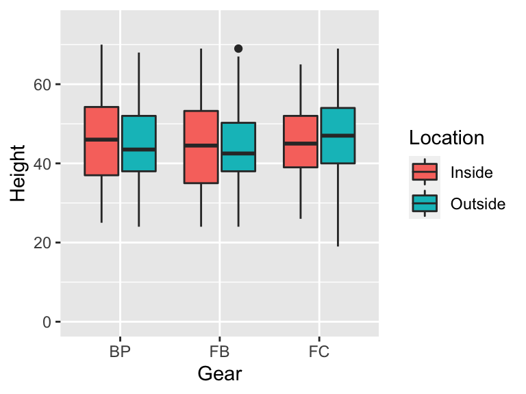

```r
SamplingNew<-SamplingOne[c(1:320,353:608),]
ggplot(data = SamplingNew, aes(x = Gear, y = Height, fill=Location))+geom_boxplot()+scale_y_continuous(limits=c(0,75))
```

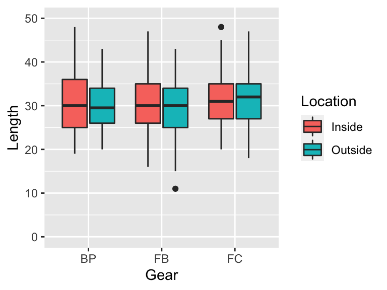

```r
ggplot(data = SamplingNew, aes(x = Gear, y = Length, fill=Location))+geom_boxplot()+scale_y_continuous(limits=c(0,50))
```

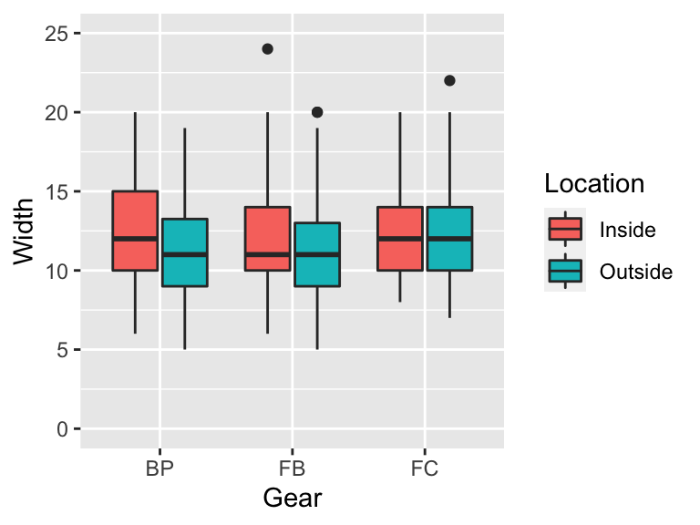

```r
ggplot(data = SamplingNew, aes(x = Gear, y = Width, fill=Location))+geom_boxplot()+scale_y_continuous(limits=c(0,25))
```